# Final_R_reference_guide

Nicole Yunes Perez

2022-12-19

# R Reference Guide

## Loading Data and Packages

```r
require (here)
```

```
## here() starts at C:/Users/nikol/OneDrive/Documents/ECO602/environmental_data/Course-Project
```

```r
library (palmerpenguins)
require (palmerpenguins)
here()
```

```
## [1] "C:/Users/nikol/OneDrive/Documents/ECO602/environmental_data/Course-Project"
```

```r
ginkgo<- read.csv(here("docs","data", "ginkgo_data_2021.csv"))
penguins<- palmerpenguins::penguins
```

In this section, I have loaded my built in data (palmerpenguins), installed the “here” package, require said package and then used that function and read.csv to load it into a dataframe called gingko. with the here function you can specify in which folders the document lives

## Data Structures

### The C function

The function c() combines or concatenates its arguments into a vector (a 1-dimensional data structure consisting of 1 or more elements).

All of the elements must be of the same type. I can’t combine character and numeric types in the same call to c() Here’s two examples using numeric and character data types:

```r
num_vec  = c(1, 4, 8, 9, 13)

char_vec = c("a", "fish", "data is cool")
```

I can show the contents of a vector by typing the name of the vector, or using the print() function.

```r
num_vec
```

```
## [1]  1  4  8  9 13
```

[1] 1 4 8 9 13

```r
print(char_vec)
```

```
## [1] "a"            "fish"         "data is cool"
```

[1] “a” “fish” “data is cool”

### The Length Function

The function length() tells us the length of a vector. For example, when used with our previous vector:

```r
length(num_vec)
```

```
## [1] 5
```

Here the function length() tells us that there are 5 numbers in this vector.

### The Matrix Function

This function allows us to build a matrix, with any specified number of rows and columns. You must specify which data you will use for this matrix.

```r
number_matrix<- matrix(num_vec, 1, 5)
char_matrix<- matrix(char_vec, 1, 3)
```

So in this example, I’ve created a matrix with our previous number vector and put those numbers into a matrix with 1 row and 5 columns. The number of rows and columns must be a multiple of the data length, in this case that is 5.

### The data.frame Function

```r
num_df<- data.frame(number_matrix, char_matrix)
```

This function allows us to create a dataframe and congregate multiple matrices togethe. This is usually the level which we perform data analysis at.

### Ginkgo nrow

```r
nrow(ginkgo)
```

```
## [1] 756
```

This function is fairly simple, and it just tells us the number of rows in any object already defined. In this case it is 756 rows.

### Ginkgo ncol

```r
ncol(ginkgo)
```

```
## [1] 6
```

### Ginkgo dim

```r
dim(ginkgo)
```

```
## [1] 756   6
```

The dim() function tells us both the number of rows and the number of columns. It first lists the number of rows and then the number of columns.

## Subsetting

### $ for subsetting

We can use the ‘$’ symbol to subset a part of our dataframe using the name of the row or column.

```r
seeds<- ginkgo$seeds_present
```

In this example we’ve subsetted only the column which tells us if there are any seeds present.

### [] for subsetting

We can also use brackets to specify a specific row/column or combination of those.

```r
first.row.ginkgo<- ginkgo[1,]
row.2.col.3.ginkgo<- ginkgo[2,3]
third.col.ginkgo<- ginkgo[,3]
```

If you would only like to select an entire row or column, you must use an empty space and comma to represent no row/column was selected.

## Numerical Data Exploration

### Summary Function

If you would like to see a quick summary of your data, the summary function gives you a quick snapshot of some simple data exploration of your dataframe.

```r
summary(ginkgo)
```

```
##     site_id      seeds_present     max_width        max_depth
##  Min.   : 1896   Mode :logical   Min.   : 16.00   Min.   : 19.00
##  1st Qu.: 3703   FALSE:636       1st Qu.: 63.00   1st Qu.: 43.00
##  Median : 6066   TRUE :120       Median : 74.00   Median : 51.00
##  Mean   : 6079                   Mean   : 74.34   Mean   : 58.51
##  3rd Qu.: 7206                   3rd Qu.: 85.00   3rd Qu.: 66.00
##  Max.   :12982                   Max.   :130.00   Max.   :145.00
##
##   notch_depth    petiole_length
##  Min.   : 0.00   Min.   :  8.00
##  1st Qu.: 0.00   1st Qu.: 34.00
##  Median : 0.00   Median : 47.00
##  Mean   : 2.99   Mean   : 48.25
##  3rd Qu.: 4.00   3rd Qu.: 60.00
##  Max.   :49.00   Max.   :113.00
##                  NA's   :4
```

This function will give you a range, mean, mode, and median of all the matrices in your dataframe.

### Mean Function

This function is pretty self explanatory. It tells you the mean/average of your specified dataset. You must specify which column you would like a mean of if there are multiple columns in your dataset.

```r
mean(ginkgo$max_width)
```

```
## [1] 74.33823
```

In this example, I’ve specified that I’d like to know the mean of the max_width for my ginkgo dataset and R tells us the mean is 74.34. You can also find this information from the summary function.

### Standard Deviation Function

This function tells us what the standard deviation of our data looks like. Again, you must specify which column you would like to look at.

```r
sd(ginkgo$max_width)
```

```
## [1] 16.4203
```

In this example, R tells us the standard deviation of our max_width is 16.42.

## Graphical Data Exploration

### The Plot Function

The plot function creates a scatterplot for us. You must specify what you want your x and y data to be using our subsetting functions.Our x goes first followed by the Y.

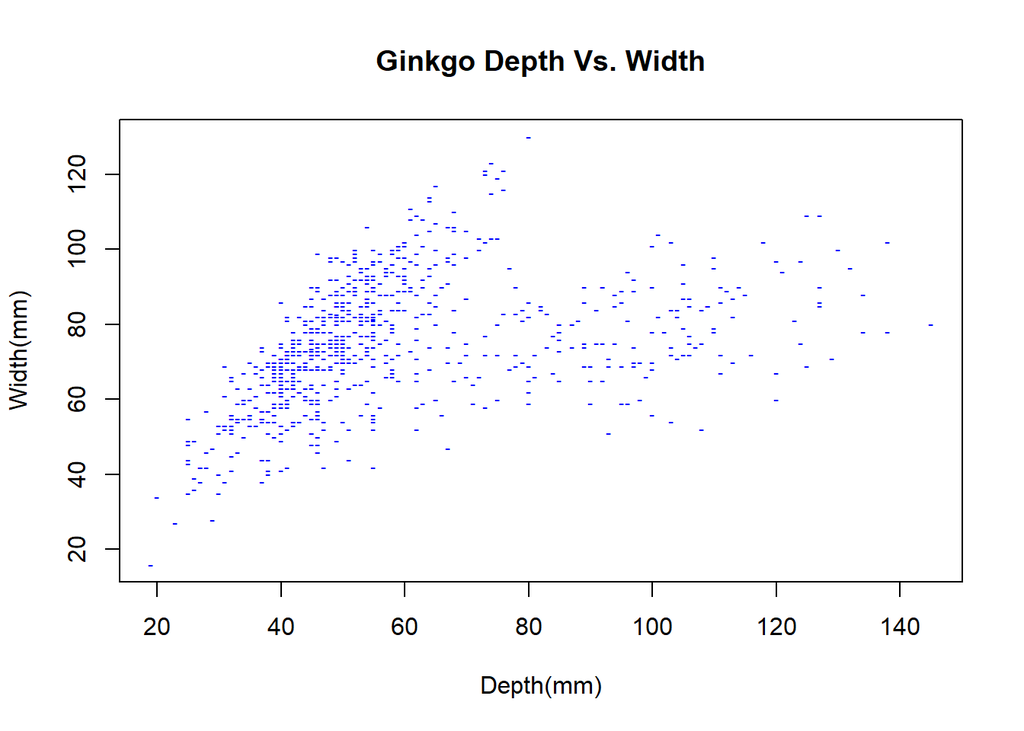

```r
plot(ginkgo$max_depth, ginkgo$max_width, col= "blue", main= "Ginkgo Depth Vs. Width", pch=45, cex=.7, xlab = "Depth(mm)", ylab = "Width(mm)", ylim = NULL, xlim= NULL)
```

### The Histogram Function

This function allows us to create a histogram. The breaks argument allows us to change the number of breaks between each bar.

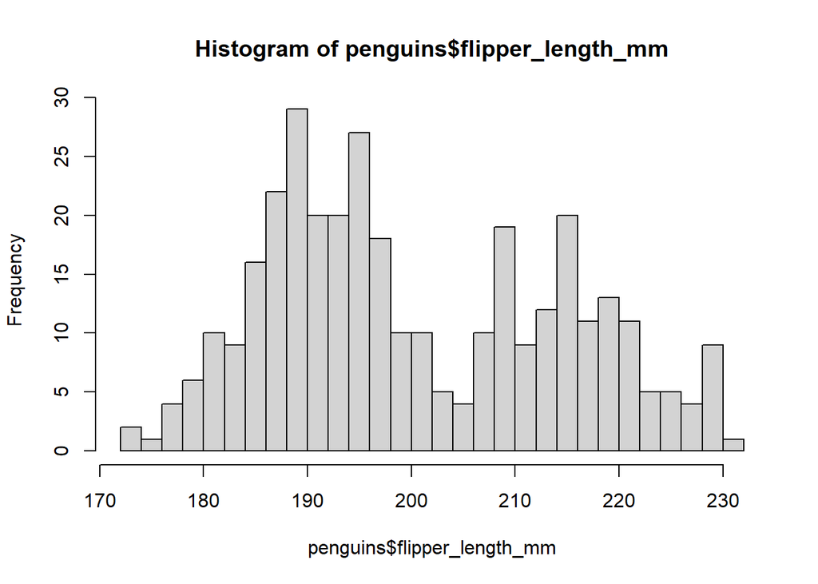

```r
hist(penguins$flipper_length_mm, breaks = 25)
```

### The Boxplot and Par Function

The Boxplot function allows us to make a boxplot from any data set. You can also use the Par function to create multiple panels with multiple graphs. You can also create conditional box plots where you can specify specific categories to base the plot on. Here’s two examples of each

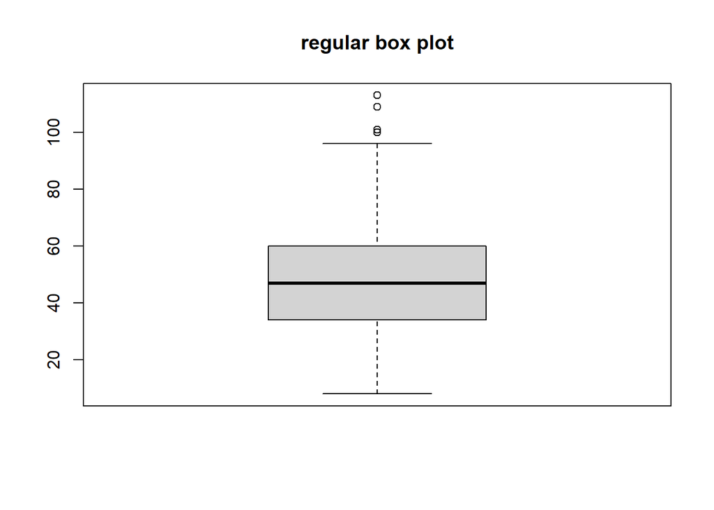

```r
boxplot(ginkgo$petiole_length, main= "regular box plot")
```

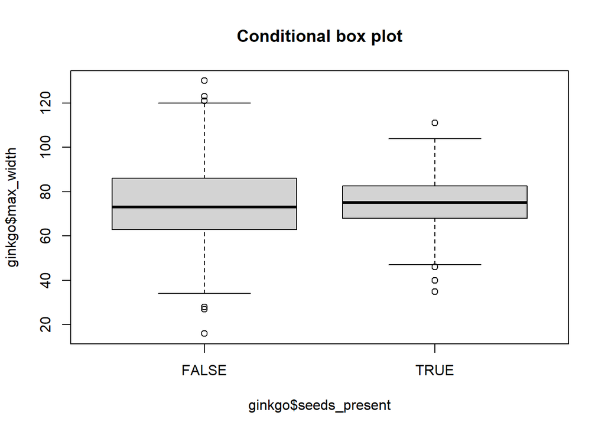

```r
boxplot(ginkgo$max_width ~ ginkgo$seeds_present, main="Conditional box plot")
```

Now let’s creat a four panel figure of histograms

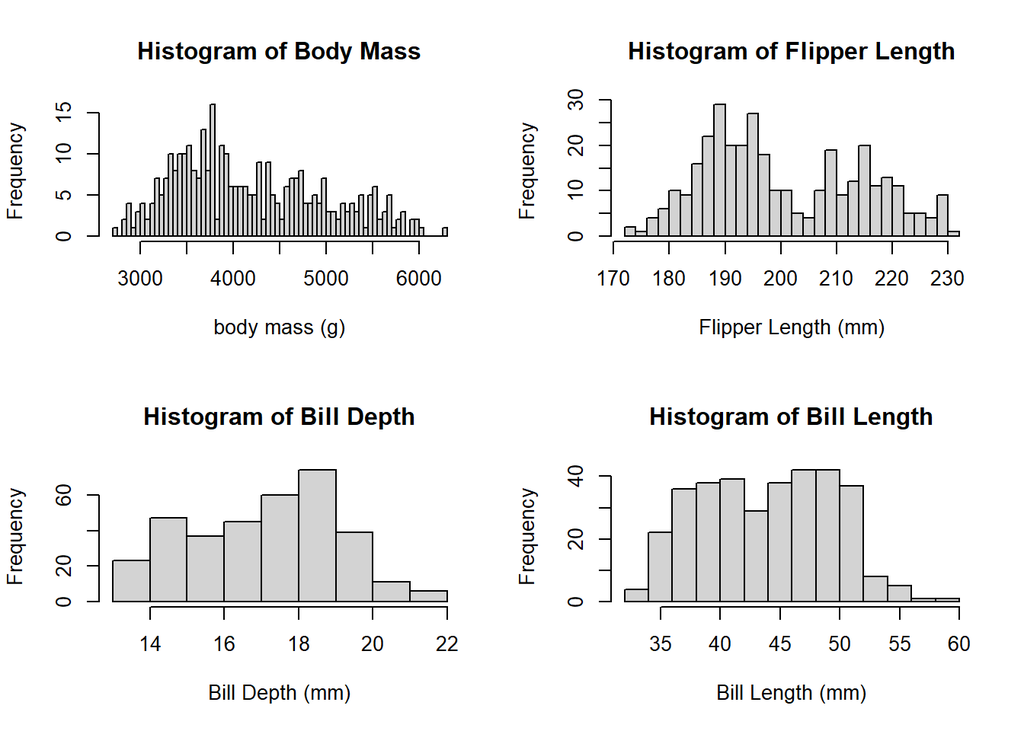

```r
par(mfrow=c(2,2))
  hist(penguins$body_mass_g, breaks = 80, main = "Histogram of Body Mass", xlab = "body mass (g)")
  hist(penguins$flipper_length_mm, breaks = 25, main = "Histogram of Flipper Length", xlab = "Flipper Length (mm)")
  hist(penguins$bill_depth_mm, main = "Histogram of Bill Depth", xlab = "Bill Depth (mm)")
  hist(penguins$bill_length_mm, main="Histogram of Bill Length", xlab="Bill Length (mm)")
```

## Distribution Functions

### The Probability Density Function

This function is used when predicting the likelihood of an exact event in a continuous distribution.

```r
dnorm(7.5, mean =10, sd= 3 )
```

```
## [1] 0.09397063
```

In this example, we have a 9% chance of observing a value of exactly 7.5.

### The Cumulative Density Function

This function is used when predicting the likelihood of an event occurring within some range in a continuous distribution.

```r
pnorm(7.5, mean = 10, sd= 3)
```

```
## [1] 0.2023284
```

In this example, we have a 20% chance of observing a value of 7.5 or less.

### The Quantile Function (continuous)

This function is used when trying to figure out a percentile within a continuous distribution.

```r
qnorm(0.75, mean= 10, sd= 3)
```

```
## [1] 12.02347
```

In this example we’re looking for the 75th percentile which begins at 12.02.

### The Probability Mass Function

This function is used when predicting the likelihood of observing an exact value in a discrete distribution.

```r
dbinom(3, 4, 0.75)
```

```
## [1] 0.421875
```

In this example, the probability of observing exactly 3 in a discrete distribution of a sample size of 4 and 75% probability is 42%.

### The Cumulative Mass Function

This function allows us to predict an observation will fall within a certain range.

```r
pbinom(3, 4, 0.75)
```

```
## [1] 0.6835937
```

In this example, the probability of observing a value of 3 or less is 68%

### The Quantile Function (Discrete Distribution)

```r
qbinom(0.75, 4, 0.75)
```

```
## [1] 4
```

In this example, the 75th percentile begins at the value 4 for this discrete distribution.